# DA5020 – Assignment 3

```r
library(tibble)
library(readr)
library(tidyr)
library(plyr)
library(dplyr)
library(Hmisc)
library(scales)
```

## Question 1

In your own words, compare and contrast a tibble with a dataframe (definition only)

Dataframes are used for storing data in table form with n cols and n rows. Tibbles are dataframes with some additional functionality and behave differently when subsetting and printing. Notably, printing tibbles allow viewing the data type in each column of the table.

## Question 2 (10.5 Exercises)

#### 1. How can you tell if an object is a tibble? (Hint: try printing mtcars, which is a regular data frame).

Tibbles can be checked using `is_tibble()`

```r
is_tibble(mtcars)
```

```
[1] FALSE
```

#### 2. Compare and contrast the following operations on a data.frame and equivalent tibble. What is different? Why might the default data frame behaviours cause you frustration?

```r
df <- data.frame(abc = 1, xyz = "a")
df$x
```

```
[1] a
Levels: a
```

```r
df[, "xyz"]
```

```
[1] a
Levels: a
```

```r
df[, c("abc", "xyz")]
```

| abc | xyz |
| --- | --- |
| 1 | a |

`df$x` may cause confusion because it returns the contents of `df$xyz` even though there is no `x` column. The contents of `df$xyz` is also coerced to a factor which may not be desirable and can be avoided by specifying `stringsAsFactors = FALSE`

```r
df <- data.frame(abc = 1, xyz = "a", stringsAsFactors = FALSE)
df[, "xyz"]
```

```
[1] "a"
```

#### 3. If you have the name of a variable stored in an object, e.g. `var <- "mpg"`, how can you extract the reference variable from a tibble?

The variable `mpg` can be extracted from a tibble by `tibble$mpg`

#### 4. Practice referring to non-syntactic names in the following data frame

```r
annoying <- tibble(
  `1` = 1:10,
  `2` = `1` * 2 + rnorm(length(`1`))
)
```

1. Extracting the variable called `1`

```r
annoying$`1`
```

```
 [1]  1  2  3  4  5  6  7  8  9 10
```

2. Plotting a scatterplot of `1` vs `2`

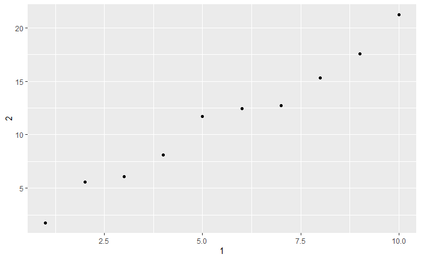

```r
ggplot(annoying,
       aes(x = `1`,
           y = `2`)) +
  geom_point()
```

3. Creating a new column called `3` which is `2` divided by `1`.

```r
annoying <- annoying %>% mutate(`3` = `2`/`1`)
annoying
```

| 1 | 2 | 3 |
| --- | --- | --- |
| 1 | 1.769823 | 1.769823 |
| 2 | 5.558708 | 2.779354 |
| 3 | 6.070508 | 2.023503 |
| 4 | 8.129288 | 2.032322 |
| 5 | 11.715065 | 2.343013 |
| 6 | 12.460916 | 2.076819 |
| 7 | 12.734939 | 1.819277 |
| 8 | 15.313147 | 1.914143 |
| 9 | 17.554338 | 1.950482 |
| 10 | 21.224082 | 2.122408 |

4. Renaming the columns to `one`, `two` and `three`

```r
colnames(annoying) <- c("one", "two", "three")
annoying
```

| one | two | three |
| --- | --- | --- |
| 1 | 1.769823 | 1.769823 |
| 2 | 5.558708 | 2.779354 |
| 3 | 6.070508 | 2.023503 |
| 4 | 8.129288 | 2.032322 |
| 5 | 11.715065 | 2.343013 |
| 6 | 12.460916 | 2.076819 |
| 7 | 12.734939 | 1.819277 |
| 8 | 15.313147 | 1.914143 |
| 9 | 17.554338 | 1.950482 |
| 10 | 21.224082 | 2.122408 |

5. What does `tibble::enframe()` do? When might you use it?

`tibble::enframe()` converts a vector or list to a dataframe. This may be used to organize the list output from functions such as `lapply()`

```r
# enframe(unlist(lapply(mtcars, mean)),
#         name  = "var",
#         value = "mean")

lapply(mtcars, mean) %>%
  unlist() %>%
  enframe(name  = "var",
    value = "mean")
```

| var | mean |
| --- | --- |
| mpg | 20.090625 |
| cyl | 6.187500 |
| disp | 230.721875 |
| hp | 146.687500 |
| drat | 3.596563 |
| wt | 3.217250 |
| qsec | 17.848750 |
| vs | 0.437500 |
| am | 0.406250 |
| gear | 3.687500 |

[output cut: 1 more lines]

6. What option controls how many additional column names are printed at the footer of a tibble?

Additional column names printed at the footer of a tibble can be specified using `options(tibble.width = n, tibble.max_extra_cols = n)`

## Question 3.1

Load the data into an appropriate data object of your choice (dataframe or tibble). Note that the data file is compressed so you need to determine an appropriate way to extract the file (this must be done programmatically).

```r
temp <- tempfile()
download.file(url = "http://ds4100.weebly.com/uploads/8/6/5/9/8659576/bird_strikes.zip",
              destfile = temp)
bird_strikes <- read_csv(unzip(zipfile = temp),
                                   na = c("", "NA"),
                         guess_max = 90000)
unlink(temp)
```

## Question 3.2

Inspect the data and the data types in each field (Hint: you can use the glimpse function)

```r
glimpse(bird_strikes)
```

```
Rows: 99,404
Columns: 37
$ `Aircraft: Type`                             <chr> "Airplane", "Airplane", "Airplane", "Airplane...
$ `Airport: Name`                              <chr> "NEWARK LIBERTY INTL ARPT", "UNKNOWN", "DENVE...
$ `Altitude bin`                               <chr> "< 1000 ft", "Unknown", "Unknown", "Unknown",...
$ `Aircraft: Make/Model`                       <chr> "B-757-200", "B-737-300", "B-737-300", "B-727...
$ `Wildlife: Number struck`                    <chr> "2 to 10", "1", "1", "1", "1", "1", "1", "1",...
$ `Effect: Impact to flight`                   <chr> NA, NA, NA, NA, NA, "Other", "None", "None", ...
$ `Effect: Other`                              <chr> NA, NA, NA, NA, NA, "DECREASED SPEED", NA, NA...
$ `Location: Nearby if en route`               <chr> NA, NA, NA, NA, NA, "FL", NA, NA, NA, NA, NA,...
$ `Aircraft: Flight Number`                    <chr> "586", NA, NA, NA, NA, NA, NA, NA, NA, NA, "6...
$ FlightDate                                   <chr> "1/1/2000 0:00", "1/1/2000 0:00", "1/1/2000 0...
$ `Record ID`                                  <dbl> 200508, 206593, 206594, 204095, 202963, 20312...
$ `Effect: Indicated Damage`                   <chr> "No damage", "No damage", "No damage", "No da...
$ `Location: Freeform en route`                <chr> NA, "HDN-LAX", NA, NA, NA, "5 MI N HOMESTEAD ...
```

[output cut: 24 more lines]

## Question 3.3

Format the column names to be one contiguous word; i.e remove the period(s) ‘.’. E.g. Record.ID should be RecordID or Record..ID should also be RecordID. Update the respective column names in the dataframe or tibble and display them

Spaces are not collapsed to periods when data is imported using `check.names = FALSE`, however spaces can be collapsed to make contiguous words by `gsub()`

```r
colnames(bird_strikes) <- gsub(" ", "", colnames(bird_strikes))
colnames(bird_strikes)[1:10]
```

```
 [1] "Aircraft:Type"            "Airport:Name"             "Altitudebin"
 [4] "Aircraft:Make/Model"      "Wildlife:Numberstruck"    "Effect:Impacttoflight"
 [7] "Effect:Other"             "Location:Nearbyifenroute" "Aircraft:FlightNumber"
[10] "FlightDate"
```

## Question 3.4

Display descriptive statistics for the data and show the frequency of missing values.

```r
apply(bird_strikes, MARGIN = 2, describe)
```

```
$`Aircraft:Type`
newX[, i]
       n  missing distinct
   74532    24872        3

Value        Airplane          C Helicopter
Frequency       73521          1       1010
Proportion      0.986      0.000      0.014

$`Airport:Name`
newX[, i]
       n  missing distinct
   99395        9     1703

lowest : ABERDEEN REGIONAL AR         ABILENE REGIONAL ARPT        ABRAHAM LINCOLN CAPITAL ARPT ACADIANA REGIONAL ARPT       ADA MUNICIPAL ARPT
highest: YUMA MCAS/YUMA INTL ARPT     ZAMPERINI FIELD ARPT         ZELIENOPLE MUNICIPAL         ZEPHYRHILLS MUNICIPAL ARPT   ZURICH

$Altitudebin
newX[, i]
       n  missing distinct
   99404        0        3

Value      < 1000 ft > 1000 ft   Unknown
Frequency      43901     11548     43955
Proportion     0.442     0.116     0.442

$`Aircraft:Make/Model`
newX[, i]
       n  missing distinct
   99404        0      526

lowest : A-10A          A-23 MUSKATEER A-300          A-310          A-318
highest: WC-130H        WC-130J        WC-135C        WC-135W        ZODIAC CH601

$`Wildlife:Numberstruck`
newX[, i]
       n  missing distinct
   91721     7683        4

Value              1 11 to 100   2 to 10  Over 100
```

[output cut: 293 more lines]

```
       n  missing distinct
     107    99297        5

lowest :  1  2  3  4  6, highest:  1  2  3  4  6

Value          1     2     3     4     6
Frequency     84    18     2     2     1
Proportion 0.785 0.168 0.019 0.019 0.009

$`Speed(IAS)inknots`
newX[, i]
       n  missing distinct
   38729    60675      244

lowest :    0    1    2    3    4, highest:  450  480  500 2500 9999
```

Check for missing values in columns

```r
apply(bird_strikes,
      MARGIN = 2,
      function(x) sum(is.na(x))) %>%
  sort(decreasing = TRUE)
```

```
               Numberofpeopleinjured              Numberofhumanfatalities
                               99297                                98312
            Location:Nearbyifenroute                         Effect:Other
                               98113                                97764
Cost:Aircrafttimeoutofservice(hours)             Location:Freeformenroute
                               92021                                89369
                       Reported:Date                Aircraft:FlightNumber
                               71537                                62202
                   Speed(IAS)inknots        Pilotwarnedofbirdsorwildlife?
                               60675                                58582
            Conditions:Precipitation                       Conditions:Sky
                               51749                                50151
                     When:Time(HHMM)                     Milesfromairport
                               48932                                47683
                     Feetaboveground                Effect:Impacttoflight
                               43955                                43179
                      When:Timeofday                   When:Phaseofflight
                               36920                                34738
           Aircraft:Numberofengines?                        Aircraft:Type
                               31059                                24872
                             Remarks                        Wildlife:Size
                               17086                                13289
               Wildlife:Numberstruck                     Wildlife:Species
                                7683                                   20
                        Airport:Name                          Altitudebin
                                   9                                    0
                 Aircraft:Make/Model                           FlightDate
                                   0                                    0
                            RecordID               Effect:IndicatedDamage
                                   0                                    0
           Aircraft:Airline/Operator                          OriginState
                                   0                                    0
         Remainsofwildlifecollected?   RemainsofwildlifesenttoSmithsonian
                                   0                                    0
            Cost:Other(inflationadj)            Cost:Repair(inflationadj)
                                   0                                    0
                         Cost:Total$
                                   0
```

Check for missing values in rows

```r
row_nas <- apply(bird_strikes,
                 MARGIN = 1,
                 function(x) sum(is.na(x)))

## rows with missing values
which(row_nas >= 1) %>% length()
```

```
[1] 99404
```

## Question 3.5a Remove rows which are primarily (75%) empty

```r
bird_strikes_bk <- bird_strikes ## backup

bird_strikes <- bird_strikes[!(row_nas >= ncol(bird_strikes) * 0.75), ]

dim(bird_strikes)
```

```
[1] 99404    37
```

```r
## all rows are at least 25% complete. none removed
```

## Question 3.5b

Calculate and impute the median of a continuous field of your choice. *Calculate median of total cost of a bird strike*

```r
# calculate median
median_cost <- bird_strikes %>%
  filter(`Cost:Total$` != 0) %>% ## exclude missing values coerced to 0s during import
  select(`Cost:Total$`) %>%
  summarise(median = median(`Cost:Total$`, na.rm = TRUE)) %>%
  pull()
median_cost
```

```
[1] 8018
```

```r
## additional total cost stats
bird_strikes %>%
    filter(`Cost:Total$` != 0) %>%
    select(`Cost:Total$`) %>% summary()
```

```
  Cost:Total$
 Min.   :       1
 1st Qu.:     899
 Median :    8018
 Mean   :  140675
 3rd Qu.:   42204
 Max.   :37948803
```

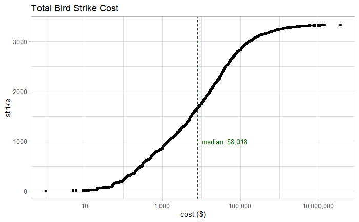

```r
## quick plot of median
all_costs <- bird_strikes %>%
    filter(`Cost:Total$` != 0) %>%
    pull(`Cost:Total$`)

qplot(sort(all_costs),
      seq_along(all_costs)) +
  scale_x_continuous(trans = "log10",
                     labels = comma) +
  geom_vline(xintercept = median_cost,
             linetype   = "dashed",
             colour     = "darkgreen") +
  geom_text(aes(
    x      = median_cost * 5,
    label  = paste0("median: $", comma(median_cost)),
    y      = 1000),
    colour = "darkgreen",
    size   = 3.5) +
  labs(title = "Total Bird Strike Cost",
       x     = "cost ($)",
       y     = "strike") +
  theme_light()
```

```r
## fill in median
bird_strikes$`Cost:Total$` <- gsub("^0$", median_cost, bird_strikes$`Cost:Total$`) %>% as.numeric()
```

## Question 3.5c

Derive and impute the mode for a categorical field of your choice

```r
## consider aircraft type
## get counts and visualize
aircraft_counts <- bird_strikes %>%
  add_count(`Aircraft:Type`) %>%
  distinct(`Aircraft:Type`, `n`)

aircraft_counts
```

| Aircraft:Type | n |
| --- | --- |
| Airplane | 73521 |
| NA | 24872 |
| Helicopter | 1010 |
| C | 1 |

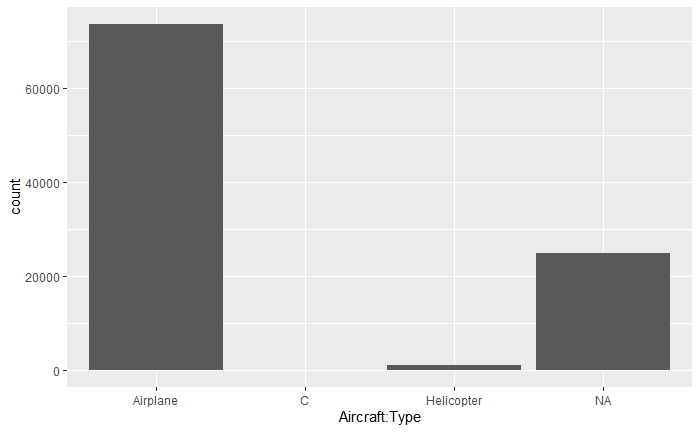

```r
ggplot(data = bird_strikes,
       aes(x = `Aircraft:Type`)) + geom_bar()
```

Impute mode and check results

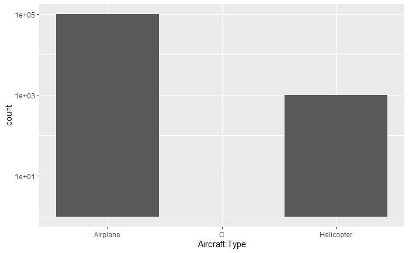

```r
bird_strikes$`Aircraft:Type`[is.na(bird_strikes$`Aircraft:Type`)] <-
  aircraft_counts %>%
  filter(`n` == max(aircraft_counts$n)) %>%
  pull(`Aircraft:Type`)

ggplot(data = bird_strikes,
       aes(x = `Aircraft:Type`)) +
  geom_bar() +
  scale_y_continuous(trans = "log10")
```

## Question 3.6

Construct a bar chart showing the total EffectIndicatedDamage for each category. — (10 points)

```r
damage_count <- bird_strikes %>%
  group_by(`Aircraft:Type`) %>%
  add_count(`Effect:IndicatedDamage`) %>%
  select(`Aircraft:Type`,`Effect:IndicatedDamage`, `n`) %>%
  distinct() %>%
  ungroup() %>%
  slice(-n())  ## remove one observation for 'C'

damage_count
```

| Aircraft:Type | Effect:IndicatedDamage | n |
| --- | --- | --- |
| Airplane | No damage | 91126 |
| Airplane | Caused damage | 7267 |
| Helicopter | No damage | 737 |
| Helicopter | Caused damage | 273 |

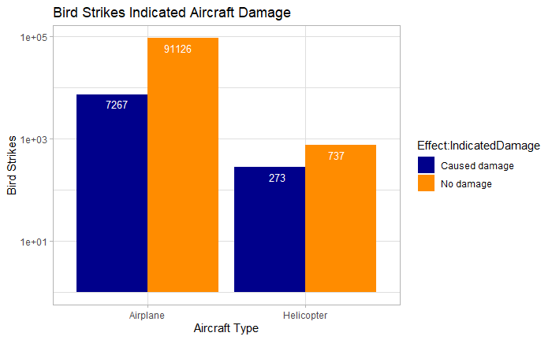

```r
ggplot(data = damage_count,
       aes(fill = `Effect:IndicatedDamage`,
           y    = `n`,
           x    = `Aircraft:Type`)) +
    geom_bar(position = "dodge",
             stat     = "identity") +
    scale_y_continuous(trans  = "log10",
                       labels = scientific) +
    scale_fill_manual(values  = c("darkblue", "darkorange")) +
    geom_text(aes(
        label = `n`),
        vjust = 1.6,
        hjust = c(-0.6, 1.9, -1.4, 2.2),
        color = "white",
        size  = 3.5) +
    labs(title = "Bird Strikes Indicated Aircraft Damage",
         x     = "Aircraft Type",
         y     = "Bird Strikes") +
    theme_light()
```

## Question 3.7

```r
bird_strikes %>%
  filter(`Effect:IndicatedDamage` == "Caused damage",
         `Pilotwarnedofbirdsorwildlife?` == "Y") %>%
  dplyr::count() %>%
  pull()
```

```
[1] 1422
```

## Question 3.8

For the events that did not cause any damages, how many aircraft type were aircraft and helicopters;

```r
## damage count by aircraft (calculated in Question 3.6)
damage_count
```

| Aircraft:Type | Effect:IndicatedDamage | n |
| --- | --- | --- |
| Airplane | No damage | 91126 |
| Airplane | Caused damage | 7267 |
| Helicopter | No damage | 737 |
| Helicopter | Caused damage | 273 |

And what was the most common WildlifeSpecies that was struck. — (10 points)  
*The most common known species is the Mourning dove*

```r
bird_strikes %>%
  add_count(`Wildlife:Species`) %>%
  select(`Wildlife:Species`,
         `n`) %>%
  distinct() %>%
  arrange(desc(`n`))
```

| Wildlife:Species | n |
| --- | --- |
| Unknown bird - medium | 23416 |
| Unknown bird - small | 18567 |
| Unknown bird or bat | 4411 |
| Mourning dove | 4365 |
| Gulls | 2795 |
| American kestrel | 2651 |
| Killdeer | 2601 |
| European starling | 2200 |
| Horned lark | 2041 |
| Unknown bird | 1932 |

[output cut: 599 more lines]